# Determining Factors that lead to a successfull Wrestling Career

Samuel Condori

2024-02-27

## Homework 3

You’ve got text, ratings, and any other information available to you from the cagematch site. Perform any type of model and report your results.

# Data Scrapping

```r
library(rvest)
library(magrittr)
library(stringr)
library(dplyr)
```

```r
# Get into the URL of each wrestler
all_links <- read_html(url("https://www.cagematch.net/?id=2&view=statistics")) %>%
  html_elements("a[href*='gimmick']") %>%
  html_attr("href") %>%
  paste0("https://www.cagematch.net/", .)

# Remove the first two elements from all_links
all_links <- all_links[-c(1, 2)]

all_links <- gsub("&gimmick=([^&]+)",
                  "",
                  all_links)

# Create function that will extract Fighter Information from their Overview page

overview_info<- function(html_content) {
  html <- read_html(url(html_content))
  info <- html %>%
    html_elements(".InformationBoxRow") %>%
    html_text(trim = TRUE)
# Not all fighters have the same information, so we will filter the information and give NA where they dont have it
  keywords <- c("Birthplace", "Gender", "Height", "Weight", "Background in sports", "In-ring experience", "Wrestling style")
# Initialize an empty dataframe
  df <- data.frame(matrix(ncol = length(keywords), nrow = 1))
  names(df) <- keywords
# Use a for loop to extract the info and assign NA values if the info is not present
  for (i in keywords) {
    pattern <- paste0(i, ":")
    matched_info <- grep(pattern, info, value = TRUE)
    value <- ifelse(length(matched_info) > 0, sub(".*: ", "", matched_info), NA)
    df[1, i] <- value
  }
  return(df)
}


# Apply function
fighter_data <- do.call(rbind,lapply(all_links, overview_info))


# Cleaning the info in the data, since the each row still have the pattern in the information extracted
keyword_remover <- function(df) {
  cleaned_df <- as.data.frame(lapply(df, gsub, pattern = ".*?:\\s*", replacement = ""))
  return(cleaned_df)
}

fighter_data <- keyword_remover(fighter_data)

# Cleaning the data:
#Extract Height in Cm abd Weight in Kg from the parenthesis
#Extract the Country from the Birthplace
#Extract number from years of experience
extract_numeric_values <- function(df) {
  df$Height <- gsub(".*\\((\\d+) cm\\).*", "\\1", df$Height)
  df$Weight <- gsub(".*\\((\\d+) kg\\).*", "\\1", df$Weight)
  df$Country <- gsub(".*,\\s*(.*)$", "\\1", df[["Birthplace"]], ignore.case = TRUE)
  df$In.ring.experience <- gsub("\\D", "",df$In.ring.experience)
  return(df)
}

fighter_data <- extract_numeric_values(fighter_data)

# Remove the Birthplace column
fighter_data <- fighter_data %>% select(-Birthplace)

# Convert the data to numeric
list_transform <- c("Height", "Weight","In.ring.experience")

for (i in list_transform) {
  fighter_data[[i]] <- as.numeric(fighter_data[[i]])
}


head(fighter_data)
```

```
##   Gender Height Weight          Background.in.sports In.ring.experience
## 1   male    186    115                   Judo, Rugby                 25
## 2   male    185    110                        Ringen                 27
## 3   male    183    105                        Ringen                 27
## 4 female    168     63      Leichtathletik, Softball                 21
## 5 female    167     72 Karate, Basketball, Schwimmen                 30
## 6 female    163     53  Judo, Leichtathletik, Tennis                 13
##          Wrestling.style Country
## 1 Allrounder, Technician   Japan
## 2 Allrounder, Technician   Japan
## 3             Technician   Japan
## 4             Technician   Japan
## 5             Technician   Japan
## 6             Technician   Japan
```

Adding the Win and Loose scores to the data

```r
all_links <- read_html(url("https://www.cagematch.net/?id=2&view=statistics")) %>%
  html_elements("a[href*='gimmick']") %>%
  html_attr("href") %>%
  paste0("https://www.cagematch.net/", .)

all_links <- all_links[-c(1, 2)]

all_links <- gsub("&gimmick=([^&]+)",
                  "&page=22",
                  all_links)

extract_matches <- function(html_content) {
  html <- read_html(url(html_content))
  info <- html %>%
    html_elements(".InformationBoxContents") %>%
    html_text(trim = TRUE)
  return(info)
}

# Apply this function to each link
all_matches <- lapply(all_links, extract_matches)

all_matches_info <- do.call(rbind, lapply(all_matches, function(matches) data.frame(t(matches), stringsAsFactors = FALSE)))

colnames(all_matches_info) <- c("Number of Matches", "Win_Rate", "Lost_Rate", "Draw_Rate")


head(all_matches_info)
```

```
##   Number of Matches     Win_Rate    Lost_Rate  Draw_Rate
## 1              2405 1195 (49.7%) 1152 (47.9%)  58 (2.4%)
## 2              3556 1936 (54.4%) 1441 (40.5%) 179 (5.0%)
## 3              3043 1477 (48.5%) 1398 (45.9%) 168 (5.5%)
## 4               416  272 (65.4%)  136 (32.7%)   8 (1.9%)
## 5              2739 1615 (59.0%) 1009 (36.8%) 115 (4.2%)
## 6               929  444 (47.8%)  419 (45.1%)  66 (7.1%)
```

```r
# Extracting the percentage of Win, Lost, and Draw

extract_percentage <- function(df) {
  df$Win_Rate <- as.numeric(gsub(".*\\(([^%]*)%\\).*", "\\1", df$Win_Rate))
  df$Lost_Rate <- as.numeric(gsub(".*\\(([^%]*)%\\).*", "\\1", df$Lost_Rate))
  df$Draw_Rate <- as.numeric(gsub(".*\\(([^%]*)%\\).*", "\\1", df$Draw_Rate))
  return(df)
}

match_stats_df <- extract_percentage(all_matches_info)

# Unifying the fighter description with the match stats
fighter_data <- cbind(fighter_data, match_stats_df)
```

Final Formatting

```r
# Delete NA values
fighter_data <- na.omit(fighter_data)

str(fighter_data)
```

```
## 'data.frame':    69 obs. of  11 variables:
##  $ Gender              : chr  "male" "male" "male" "female" ...
##  $ Height              : num  186 185 183 168 167 163 191 194 181 185 ...
##  $ Weight              : num  115 110 105 63 72 53 107 127 101 102 ...
##  $ Background.in.sports: chr  "Judo, Rugby" "Ringen" "Ringen" "Leichtathletik, Softball" ...
##  $ In.ring.experience  : num  25 27 27 21 30 13 19 25 24 58 ...
##  $ Wrestling.style     : chr  "Allrounder, Technician" "Allrounder, Technician" "Technician" "Technician" ...
##  $ Country             : chr  "Japan" "Japan" "Japan" "Japan" ...
##  $ Number of Matches   : chr  "2405" "3556" "3043" "416" ...
##  $ Win_Rate            : num  49.7 54.4 48.5 65.4 59 47.8 45.7 65.8 53 73.9 ...
##  $ Lost_Rate           : num  47.9 40.5 45.9 32.7 36.8 45.1 53.6 22 45.5 7.7 ...
##  $ Draw_Rate           : num  2.4 5 5.5 1.9 4.2 7.1 0.8 12.2 1.4 18.4 ...
##  - attr(*, "na.action")= 'omit' Named int [1:31] 12 16 17 20 22 25 26 32 34 35 ...
##   ..- attr(*, "names")= chr [1:31] "12" "16" "17" "20" ...
```

```r
# Create dummy variables for columns with many values

# Create dummy variables for background in sports
sports_list <- unique(unlist(strsplit(fighter_data$Background.in.sports, ",\\s*")))
for(sport in sports_list) {
  fighter_data[[sport]] <- as.integer(grepl(sport, fighter_data$Background.in.sports))
}

# Create dummy variables for wrestling style
style_list <- unique(unlist(strsplit(fighter_data$Wrestling.style, ",\\s*")))
for(style in style_list) {
  fighter_data[[style]] <- as.integer(grepl(style, fighter_data$Wrestling.style))
}

# Create Dummy variables for the country
country_list <- unique(fighter_data$Country)
for(country in country_list) {
  fighter_data[[country]] <- as.integer(grepl(country, fighter_data$Country))
}
# Create Dummy variables for Gender
gender_list <- unique(fighter_data$Gender)
for(gender in gender_list) {
  fighter_data[[gender]] <- as.integer(grepl(gender, fighter_data$Gender))
}


# Formatting
fighter_data$Gender <- as.factor(fighter_data$Gender)
fighter_data$Number_of_Matches<- as.numeric(fighter_data$`Number of Matches`)
fighter_data$Win_Rate <- as.numeric(fighter_data$Win_Rate)
# Remove the columns that are not needed
fighter_data <- fighter_data %>%
  select(-Background.in.sports, -Wrestling.style,-Lost_Rate,- Draw_Rate, - Gender, -Country)
fighter_data$`Number of Matches` <- NULL
#Modify_Names
colnames(fighter_data) <- gsub("[ -]", "_", colnames(fighter_data))
```

# Modeling

```r
# Split the data into training and testing
set.seed(123)

# Create a training set
train_index <- sample(1:nrow(fighter_data), 0.8 * nrow(fighter_data))
train_data <- fighter_data[train_index, ]
test_data <- fighter_data[-train_index, ]
```

Linear Model Application

```r
# Create a linear model
lm_model <- lm(Win_Rate ~ ., data = train_data)
summary(lm_model)
```

```
##
## Call:
## lm(formula = Win_Rate ~ ., data = train_data)
##
## Residuals:
##    Min     1Q Median     3Q    Max
## -9.966 -1.124  0.000  1.685  6.632
##
## Coefficients: (12 not defined because of singularities)
##                      Estimate Std. Error t value Pr(>|t|)
## (Intercept)        -29.232783  38.205600  -0.765   0.4561
## Height               0.642157   0.290635   2.209   0.0431 *
## Weight              -0.339450   0.196833  -1.725   0.1051
## In.ring.experience   0.180126   0.167640   1.074   0.2996
## Judo                -6.417262   3.655782  -1.755   0.0996 .
## Rugby              -12.732016   6.202778  -2.053   0.0580 .
## Ringen              -8.937550   3.602102  -2.481   0.0254 *
## Leichtathletik      -6.177274   4.168994  -1.482   0.1591
## Softball                   NA         NA      NA       NA
## Karate              -9.253874   6.345177  -1.458   0.1653
## Basketball          -2.262411   3.944419  -0.574   0.5748
## Schwimmen           -6.572208   5.571495  -1.180   0.2565
## Tennis             -10.417457   9.499579  -1.097   0.2901
## Baseball            -7.673271   3.448819  -2.225   0.0419 *
## Fußball             -7.602499  10.747637  -0.707   0.4902
## Football            -5.054659   4.617325  -1.095   0.2909
## Eishockey           -8.259101   8.194781  -1.008   0.3295
## Kickboxen           15.421912   9.051403   1.704   0.1090
## Fussball             5.751934   6.868990   0.837   0.4155
## Sumo_Ringen         -3.749712   5.530526  -0.678   0.5081
## Bodybuilding        17.397750  10.198735   1.706   0.1086
## Taekwondo           22.095974   7.585692   2.913   0.0107 *
## Boxen                      NA         NA      NA       NA
## Kendo               -0.809757  14.147215  -0.057   0.9551
## Nippon_Kempo               NA         NA      NA       NA
## Gewichtheben         9.687529   8.097139   1.196   0.2501
## Volleyball         -11.516605   9.948466  -1.158   0.2651
## Segelsport                 NA         NA      NA       NA
## Soft_Tennis         -3.135056  11.202760  -0.280   0.7834
## Handball            20.041000  11.463275   1.748   0.1008
```

[output cut: 13 more lines]

```
## Österreich                 NA         NA      NA       NA
## Canada                     NA         NA      NA       NA
## Belgien                    NA         NA      NA       NA
## UK                         NA         NA      NA       NA
## Italien                    NA         NA      NA       NA
## Russland                   NA         NA      NA       NA
## male                       NA         NA      NA       NA
## female               9.999470   7.334084   1.363   0.1929
## Number_of_Matches    0.003617   0.001787   2.024   0.0612 .
## ---
## Signif. codes:  0 '***' 0.001 '**' 0.01 '*' 0.05 '.' 0.1 ' ' 1
##
## Residual standard error: 5.868 on 15 degrees of freedom
## Multiple R-squared:  0.8124, Adjusted R-squared:  0.3247
## F-statistic: 1.666 on 39 and 15 DF,  p-value: 0.1435
```

```r
# Backward Integration Model
backward_model <- step(lm_model, direction = "backward")
```

```
## Start:  AIC=203.18
## Win_Rate ~ Height + Weight + In.ring.experience + Judo + Rugby +
##     Ringen + Leichtathletik + Softball + Karate + Basketball +
##     Schwimmen + Tennis + Baseball + Fußball + Football + Eishockey +
##     Kickboxen + Fussball + Sumo_Ringen + Bodybuilding + Taekwondo +
##     Boxen + Kendo + Nippon_Kempo + Gewichtheben + Volleyball +
##     Segelsport + Soft_Tennis + Handball + Lacrosse + Kempo +
##     Turnen + Allrounder + Technician + Powerhouse + High_Flyer +
##     Brawler + Martial_Arts + Hardcore + Spot_Wrestler + Japan +
##     USA + Österreich + Canada + Belgien + UK + Italien + Russland +
##     male + female + Number_of_Matches
##
##
## Step:  AIC=203.18
## Win_Rate ~ Height + Weight + In.ring.experience + Judo + Rugby +
##     Ringen + Leichtathletik + Softball + Karate + Basketball +
##     Schwimmen + Tennis + Baseball + Fußball + Football + Eishockey +
##     Kickboxen + Fussball + Sumo_Ringen + Bodybuilding + Taekwondo +
##     Boxen + Kendo + Nippon_Kempo + Gewichtheben + Volleyball +
##     Segelsport + Soft_Tennis + Handball + Lacrosse + Kempo +
##     Turnen + Allrounder + Technician + Powerhouse + High_Flyer +
##     Brawler + Martial_Arts + Hardcore + Spot_Wrestler + Japan +
##     USA + Österreich + Canada + Belgien + UK + Italien + Russland +
##     female + Number_of_Matches
##
##
## Step:  AIC=203.18
## Win_Rate ~ Height + Weight + In.ring.experience + Judo + Rugby +
##     Ringen + Leichtathletik + Softball + Karate + Basketball +
##     Schwimmen + Tennis + Baseball + Fußball + Football + Eishockey +
##     Kickboxen + Fussball + Sumo_Ringen + Bodybuilding + Taekwondo +
##     Boxen + Kendo + Nippon_Kempo + Gewichtheben + Volleyball +
##     Segelsport + Soft_Tennis + Handball + Lacrosse + Kempo +
##     Turnen + Allrounder + Technician + Powerhouse + High_Flyer +
##     Brawler + Martial_Arts + Hardcore + Spot_Wrestler + Japan +
##     USA + Österreich + Canada + Belgien + UK + Italien + female +
##     Number_of_Matches
##
##
## Step:  AIC=203.18
```

[output cut: 469 more lines]

```
## - Leichtathletik      1     81.04 663.26 200.94
## - Turnen              1     87.68 669.91 201.49
## - female              1     92.81 675.03 201.91
## - Powerhouse          1     99.88 682.10 202.48
## - Football            1    108.88 691.10 203.20
## - Bodybuilding        1    116.74 698.96 203.82
## - Rugby               1    129.68 711.90 204.83
## - Judo                1    137.42 719.64 205.43
## - Kickboxen           1    139.67 721.90 205.60
## - Weight              1    141.22 723.45 205.72
## - Baseball            1    162.37 744.60 207.30
## - Number_of_Matches   1    164.80 747.03 207.48
## - Height              1    218.56 800.78 211.30
## - Taekwondo           1    353.34 935.57 219.86
## - Ringen              1    381.86 964.09 221.51
```

Evaluating Models

```r
library(forecast)
# Make predictions
lm_predictions <- predict(lm_model, newdata = test_data)
backward_predictions <- predict(backward_model, newdata = test_data)

# Accuracy of the models
lm_accuracy <- accuracy(lm_predictions, test_data$Win_Rate)
backward_accuracy <- accuracy(backward_predictions, test_data$Win_Rate)

lm_accuracy
```

```
##                  ME     RMSE      MAE       MPE     MAPE
## Test set -0.4170062 10.68463 8.592191 -2.163891 15.39101
```

```r
backward_accuracy
```

```
##                   ME     RMSE      MAE       MPE     MAPE
## Test set -0.00236724 9.838288 7.738435 -1.197948 13.95613
```

Random Forest Model

```r
library(randomForest)
library(caret)
# Create a random forest model
random_forest_model <- randomForest(Win_Rate ~ ., data = train_data, ntree = 100)

# Make predictions
predictions <- predict(random_forest_model, newdata = test_data)
rmse_random_forest <-sqrt(mean((predictions - test_data$Win_Rate)^2))
print(rmse_random_forest)
```

```
## [1] 9.894106
```

XGBOOST Model

```r
library(xgboost)
```

```r
# Tranforming Gender to Dummy Variable for XGBOOST

# Second Split
set.seed(123)

# Create a training set
train_index <- sample(1:nrow(fighter_data), 0.8 * nrow(fighter_data))
train_data <- fighter_data[train_index, ]
test_data <- fighter_data[-train_index, ]

# Features for training
train_features <- train_data[, -which(names(train_data) == "Win_Rate")]

# Response variable for training
train_labels <- as.numeric(train_data$Win_Rate) - 1

# Features for testing
test_features <- test_data[, -which(names(test_data) == "Win_Rate")]

# Response variable for testing
test_labels <- as.numeric(test_data$Win_Rate) - 1

# Create DMatrix for training
dtrain <- xgb.DMatrix(data = as.matrix(train_features), label = train_labels)

# Create DMatrix for testing
dtest <- xgb.DMatrix(data = as.matrix(test_features), label = test_labels)

# Train the model
set.seed(123)
bst <- xgboost(data = dtrain, # Set training data
                 eta = 0.1,
                 nrounds = 1000,
                 verbose = 1,
                 nthread = 1,
                 print_every_n = 20,
                 early_stopping_rounds = 20,
                 objective = "reg:squarederror",
                 eval_metric = "rmse")
```

```
## Will train until train_rmse hasn't improved in 20 rounds.
##
## Stopping. Best iteration:
```

```r
max_depth_vals <- c(3, 5, 7, 10, 15) # Create vector of max depth values
min_child_weight <- c(1,3,5,7, 10, 15) # Create vector of min child values
cv_params <- expand.grid(max_depth_vals, min_child_weight)
names(cv_params) <- c("max_depth", "min_child_weight")

rmse_vec <- mae_vec <- rep(NA, nrow(cv_params))


for(i in 1:nrow(cv_params)){
  set.seed(7)
  bst_tune <- xgb.cv(data = dtrain,
                   nfold = 5,
                   eta = 0.3,
                   max.depth = cv_params$max_depth[i],
                   min_child_weight = cv_params$min_child_weight[i],
                   gamma = 0.05,
                   subsample = 1,
                   colsample_bytree = 1,
                   nrounds = 150, # Set number of rounds
                   early_stopping_rounds = 20,
                   verbose = 1, # 1 - Prints out fit
                   nthread = 1, # Set number of parallel threads
                   print_every_n = 20,
                   objective = "reg:squarederror",
                   eval_metric = "rmse",
                   eval_metric = "mae")
  rmse_vec[i] <- bst_tune$evaluation_log$test_rmse_mean[bst_tune$best_iteration + 1]
  mae_vec[i] <- bst_tune$evaluation_log$test_mae_mean[bst_tune$best_iteration + 1]
}
```

[output not shown]

[output cut: 94 more lines]

```
##
## Multiple eval metrics are present. Will use test_mae for early stopping.
## Will train until test_mae hasn't improved in 20 rounds.
##
## Stopping. Best iteration:
##
## Multiple eval metrics are present. Will use test_mae for early stopping.
## Will train until test_mae hasn't improved in 20 rounds.
##
## Stopping. Best iteration:
##
## Multiple eval metrics are present. Will use test_mae for early stopping.
## Will train until test_mae hasn't improved in 20 rounds.
##
## Stopping. Best iteration:
```

```r
res_db <- cbind.data.frame(cv_params, rmse_vec, mae_vec)
res_db
```

```
##    max_depth min_child_weight rmse_vec  mae_vec
## 1          3                1 8.692091 7.211222
## 2          5                1 8.625705 7.239983
## 3          7                1 8.703207 7.361768
## 4         10                1 8.757371 7.410030
## 5         15                1 8.730400 7.383923
## 6          3                3 7.669512 6.321771
## 7          5                3 8.063536 6.780135
## 8          7                3 8.067467 6.690863
## 9         10                3 7.924881 6.592165
## 10        15                3 7.924881 6.592165
## 11         3                5 7.251319 5.976030
## 12         5                5 7.204503 5.951937
## 13         7                5 7.200556 5.951017
## 14        10                5 7.200556 5.951017
```

[output cut: 16 more lines]

Max depth =3 and minchild = 15 give the combination of lower values of RMSE and MAE

```r
subsample <- c(0.6, 0.7, 0.8, 0.9, 1) # Create vector of subsample values
colsample_by_tree <- c(0.6, 0.7, 0.8, 0.9, 1) # Create vector of col sample values

cv_params <- expand.grid(subsample, colsample_by_tree)
names(cv_params) <- c("subsample", "colsample_by_tree")

rmse_vec <- mae_vec <- rep(NA, nrow(cv_params))

for(i in 1:nrow(cv_params)){
  set.seed(7)
  bst_tune <- xgb.cv(data = dtrain,
                     nfold = 5,
                    eta = 0.1,
                    max.depth = 3,
                    min_child_weight = 15,
                    gamma = 0.05, # Set minimum loss reduction for split
                    subsample = cv_params$subsample[i],
                    colsample_bytree = cv_params$colsample_by_tree[i],
                    nrounds = 150, # Set number of rounds
                    early_stopping_rounds = 20,
                    verbose = 1, # 1 - Prints out fit
                    nthread = 1, # Set number of parallel threads
                    print_every_n = 20, # Prints out result every 20th iteration
                    objective = "reg:squarederror",
                    eval_metric = "rmse",
                    eval_metric = "mae") # Set evaluation metric
  rmse_vec[i] <- bst_tune$evaluation_log$test_rmse_mean[bst_tune$best_iteration + 1]
  mae_vec[i] <- bst_tune$evaluation_log$test_mae_mean[bst_tune$best_iteration + 1]

}
```

[output not shown]

[output cut: 69 more lines]

```
##
## Multiple eval metrics are present. Will use test_mae for early stopping.
## Will train until test_mae hasn't improved in 20 rounds.
##
## Stopping. Best iteration:
##
## Multiple eval metrics are present. Will use test_mae for early stopping.
## Will train until test_mae hasn't improved in 20 rounds.
##
## Stopping. Best iteration:
##
## Multiple eval metrics are present. Will use test_mae for early stopping.
## Will train until test_mae hasn't improved in 20 rounds.
##
## Stopping. Best iteration:
```

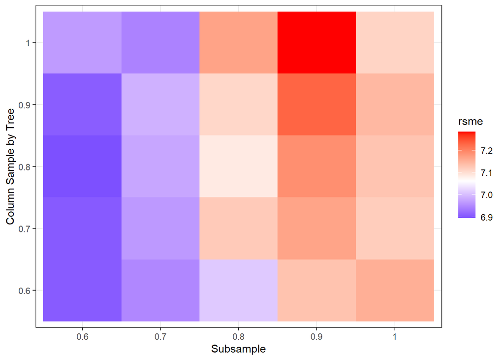

```r
res_db <- cbind.data.frame(cv_params, rmse_vec, mae_vec)
names(res_db)[3:4] <- c("rsme", "mae")
res_db$subsample <- as.factor(res_db$subsample)
res_db$colsample_by_tree <- as.factor(res_db$colsample_by_tree)


g_1 <- ggplot(res_db, aes(y = colsample_by_tree, x = subsample, fill = rsme)) +
  geom_tile() + # Use geom_tile for heatmap
  theme_bw() + # Set theme
  scale_fill_gradient2(low = "blue", # Choose low color
    mid = "white", # Choose mid color
    high = "red", # Choose high color
    midpoint =mean(res_db$rsme), # Choose mid point
    space = "Lab",
    na.value ="grey", # Choose NA value
    guide = "colourbar", # Set color bar
    aesthetics = "fill") + # Select aesthetics to apply
  labs(x = "Subsample", y = "Column Sample by Tree", fill = "rsme") # Set labels
g_1 # Generate plot
```

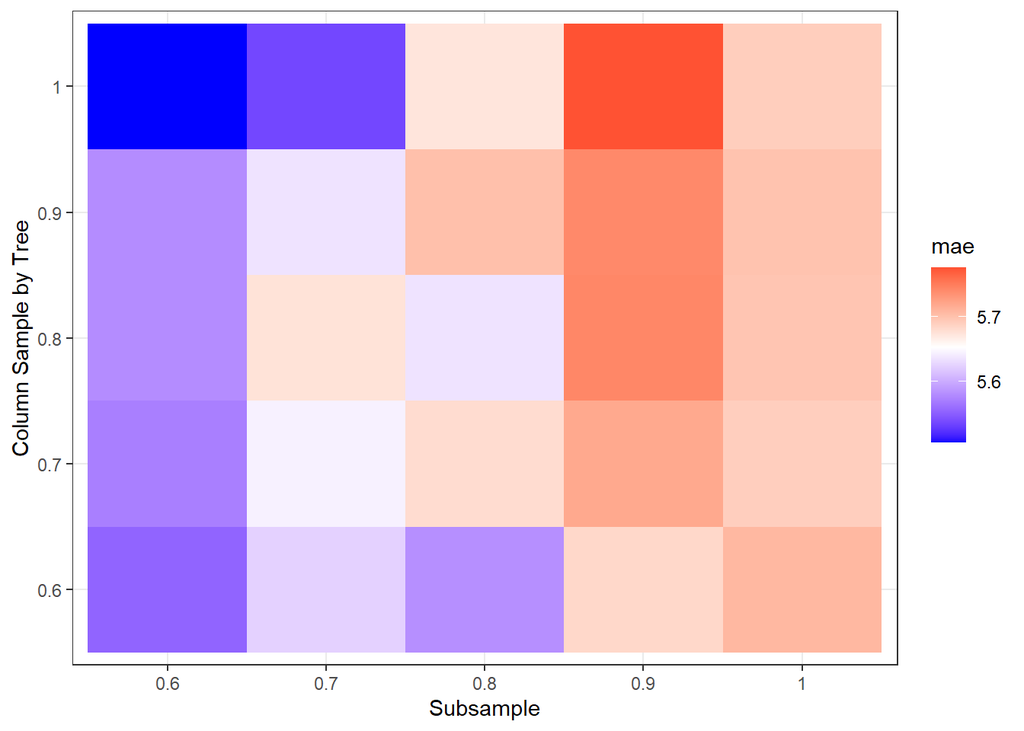

```r
g_2 <- ggplot(res_db, aes(y = colsample_by_tree, x = subsample, fill = mae)) +
  geom_tile() + # Use geom_tile for heatmap
  theme_bw() + # Set theme
  scale_fill_gradient2(low = "blue", # Choose low color
    mid = "white", # Choose mid color
    high = "red", # Choose high color
    midpoint =mean(res_db$mae), # Choose mid point
    space = "Lab",
    na.value ="grey", # Choose NA value
    guide = "colourbar", # Set color bar
    aesthetics = "fill") + # Select aesthetics to apply
  labs(x = "Subsample", y = "Column Sample by Tree", fill = "mae") # Set labels
g_2
```

```r
res_db
```

```
##    subsample colsample_by_tree     rsme      mae
## 1        0.6               0.6 6.906258 5.554051
## 2        0.7               0.6 6.948862 5.624330
## 3        0.8               0.6 7.012081 5.581729
## 4        0.9               0.6 7.131713 5.684306
## 5          1               0.6 7.154079 5.708535
## 6        0.6               0.7 6.905603 5.571450
## 7        0.7               0.7 6.965539 5.644773
## 8        0.8               0.7 7.123229 5.680495
## 9        0.9               0.7 7.166541 5.719911
## 10         1               0.7 7.120080 5.691412
## 11       0.6               0.8 6.896535 5.579923
## 12       0.7               0.8 6.978167 5.675753
## 13       0.8               0.8 7.086785 5.635935
## 14       0.9               0.8 7.189123 5.744220
## 15         1               0.8 7.130082 5.698517
## 16       0.6               0.9 6.908292 5.580054
## 17       0.7               0.9 6.989354 5.636105
## 18       0.8               0.9 7.108535 5.702207
## 19       0.9               0.9 7.229899 5.742633
## 20         1               0.9 7.143565 5.699923
## 21       0.6                 1 6.967543 5.504852
## 22       0.7                 1 6.944070 5.535714
## 23       0.8                 1 7.167631 5.673589
## 24       0.9                 1 7.283049 5.777321
## 25         1                 1 7.112520 5.691647
```

```r
bst_mod_1 <- xgb.cv(data = dtrain,
                   nfold = 5,
                   eta = 0.3,
                   max.depth = 3,
                   min_child_weight = 15,
                   gamma = 0.05,
                   subsample = 0.6,
                   colsample_bytree = 0.6,
                   nrounds = 150, # Set number of rounds
                   early_stopping_rounds = 20,
                   verbose = 1, # 1 - Prints out fit
                   nthread = 1, # Set number of parallel threads
                   print_every_n = 20,
                   objective = "reg:squarederror",
                   eval_metric = "rmse",
                   eval_metric = "mae") # Set evaluation metric
```

```
## Multiple eval metrics are present. Will use test_mae for early stopping.
## Will train until test_mae hasn't improved in 20 rounds.
##
## Stopping. Best iteration:
```

```r
bst_mod_2 <- xgb.cv(data = dtrain,
                   nfold = 5,
                   eta = 0.1,
                   max.depth = 3,
                   min_child_weight = 15,
                   gamma = 0.05,
                   subsample = 1,
                   colsample_bytree = 1,
                   nrounds = 150, # Set number of rounds
                   early_stopping_rounds = 20,
                   verbose = 1, # 1 - Prints out fit
                   nthread = 1, # Set number of parallel threads
                   print_every_n = 20,
                   objective = "reg:squarederror",
                   eval_metric = "rmse",
                   eval_metric = "mae")
```

```
## Multiple eval metrics are present. Will use test_mae for early stopping.
## Will train until test_mae hasn't improved in 20 rounds.
##
## Stopping. Best iteration:
```

```r
bst_mod_3 <- xgb.cv(data = dtrain,
                   nfold = 5,
                   eta = 0.05,
                   max.depth = 3,
                   min_child_weight = 15,
                   gamma = 0.05,
                   subsample = 1,
                   colsample_bytree = 1,
                   nrounds = 150, # Set number of rounds
                   early_stopping_rounds = 20,
                   verbose = 1, # 1 - Prints out fit
                   nthread = 1, # Set number of parallel threads
                   print_every_n = 20,
                   objective = "reg:squarederror",
                   eval_metric = "rmse",
                   eval_metric = "mae")
```

```
## Multiple eval metrics are present. Will use test_mae for early stopping.
## Will train until test_mae hasn't improved in 20 rounds.
##
## Stopping. Best iteration:
```

```r
bst_mod_4 <- xgb.cv(data = dtrain,
                   nfold = 5,
                   eta = 0.01,
                   max.depth = 3,
                   min_child_weight = 15,
                   gamma = 0.05,
                   subsample = 1,
                   colsample_bytree = 1,
                   nrounds = 150, # Set number of rounds
                   early_stopping_rounds = 20,
                   verbose = 1, # 1 - Prints out fit
                   nthread = 1, # Set number of parallel threads
                   print_every_n = 20,
                   objective = "reg:squarederror",
                   eval_metric = "rmse",
                   eval_metric = "mae")
```

```
## Multiple eval metrics are present. Will use test_mae for early stopping.
## Will train until test_mae hasn't improved in 20 rounds.
##
```

```r
bst_mod_5 <- xgb.cv(data = dtrain,
                   nfold = 5,
                   eta = 0.005,
                   max.depth = 3,
                   min_child_weight = 15,
                   gamma = 0.05,
                   subsample = 1,
                   colsample_bytree = 1,
                   nrounds = 150, # Set number of rounds
                   early_stopping_rounds = 20,
                   verbose = 1, # 1 - Prints out fit
                   nthread = 1, # Set number of parallel threads
                   print_every_n = 20,
                   objective = "reg:squarederror",
                   eval_metric = "rmse",
                   eval_metric = "mae")
```

```
## Multiple eval metrics are present. Will use test_mae for early stopping.
## Will train until test_mae hasn't improved in 20 rounds.
##
```

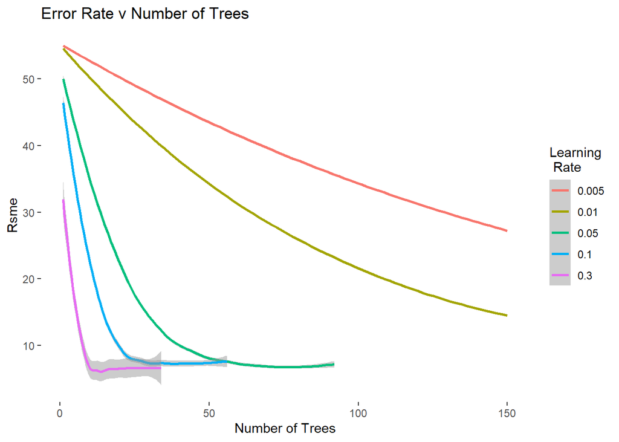

```r
# Extract results for model with eta = 0.3
pd1 <- cbind.data.frame(bst_mod_1$evaluation_log[,c("iter", "test_rmse_mean")], rep(0.3, nrow(bst_mod_1$evaluation_log)))
names(pd1)[3] <- "eta"
# Extract results for model with eta = 0.1
pd2 <- cbind.data.frame(bst_mod_2$evaluation_log[,c("iter", "test_rmse_mean")], rep(0.1, nrow(bst_mod_2$evaluation_log)))
names(pd2)[3] <- "eta"
# Extract results for model with eta = 0.05
pd3 <- cbind.data.frame(bst_mod_3$evaluation_log[,c("iter", "test_rmse_mean")], rep(0.05, nrow(bst_mod_3$evaluation_log)))
names(pd3)[3] <- "eta"
# Extract results for model with eta = 0.01
pd4 <- cbind.data.frame(bst_mod_4$evaluation_log[,c("iter", "test_rmse_mean")], rep(0.01, nrow(bst_mod_4$evaluation_log)))
names(pd4)[3] <- "eta"
# Extract results for model with eta = 0.005
pd5 <- cbind.data.frame(bst_mod_5$evaluation_log[,c("iter", "test_rmse_mean")], rep(0.005, nrow(bst_mod_5$evaluation_log)))
names(pd5)[3] <- "eta"

# Join datasets
plot_data <- rbind.data.frame(pd1, pd2, pd3, pd4, pd5)
# Converty ETA to factor
plot_data$eta <- as.factor(plot_data$eta)
# Plot points
g_3 <- ggplot(plot_data, aes(x = iter, y = test_rmse_mean, color = eta))+
  geom_smooth(alpha = 0.5) +
  theme_bw() + # Set theme
  theme(panel.grid.major = element_blank(), # Remove grid
        panel.grid.minor = element_blank(), # Remove grid
        panel.border = element_blank(), # Remove grid
        panel.background = element_blank()) + # Remove grid
  labs(x = "Number of Trees", title = "Error Rate v Number of Trees",
       y = "Rsme", color = "Learning \n Rate")  # Set labels
g_3
```

```r
bst_final <- xgb.train(data = dtrain,
                       params = list(eta = 0.3,
                                     max_depth = 3,
                                     min_child_weight = 15,
                                     gamma = 0.05,
                                     subsample = 1,
                                     colsample_bytree = 1,
                                     objective = "reg:squarederror",
                                     eval_metric = "rmse"),
                                     nrounds = 150,
                                     nthread = 1,
                                     print_every_n = 20,
                                     verbose = 1)
preds <- predict(bst_final, dtest)

rmse_xg <- sqrt(mean((preds - test_data$Win_Rate)^2))
print(rmse_xg)
```

```
## [1] 12.51098
```

Comparing all the results based on RSME:

```r
rmse_linear <- lm_accuracy[1, "RMSE"]
rmse_backward <- backward_accuracy[1, "RMSE"]
rmse_random_forest
```

```
## [1] 9.894106
```

```r
rmse_xg
```

```
## [1] 12.51098
```

```r
# Create a dataframe with the results
results <- data.frame(Model = c("Linear Model", "Backward Model", "Random Forest", "XGBoost"),
                      RMSE = c(rmse_linear, rmse_backward, rmse_random_forest, rmse_xg))
results
```

```
##            Model      RMSE
## 1   Linear Model 10.684630
## 2 Backward Model  9.838288
## 3  Random Forest  9.894106
## 4        XGBoost 12.510985
```

```r
variable_importance <- importance(random_forest_model)

# View the importance scores
print(variable_importance)
```

```
##                    IncNodePurity
## Height               258.1759935
## Weight               241.6853642
## In.ring.experience   614.5177095
## Judo                  52.3424127
## Rugby                 16.6730669
## Ringen                28.4476600
## Leichtathletik        56.2393655
## Softball               0.0000000
## Karate                 7.8295948
## Basketball             6.9581413
## Schwimmen              1.3410332
## Tennis                 7.3627811
## Baseball              18.4792592
## Fußball                8.9074276
## Football              58.3348914
## Eishockey              3.2593995
## Kickboxen             25.6831296
## Fussball               6.0342744
## Sumo_Ringen            5.7725291
## Bodybuilding           6.8853622
## Taekwondo             73.8236791
## Boxen                  0.0000000
## Kendo                  0.4120381
## Nippon_Kempo           2.1632647
## Gewichtheben           3.8767963
## Volleyball             0.9755567
## Segelsport             0.8241612
## Soft_Tennis            0.0000000
## Handball               4.9888072
## Lacrosse              31.3393704
## Kempo                  3.9468478
## Turnen                 0.2493583
## Allrounder            30.5256770
## Technician            28.1433233
## Powerhouse            31.9617290
## High_Flyer            55.2953727
## Brawler                7.8104070
## Martial_Arts           2.1014810
## Hardcore              22.1484782
## Spot_Wrestler         16.5617240
## Japan                 36.7407858
## USA                   39.1460824
## Österreich             7.0224992
## Canada                32.0155971
## Belgien                0.0000000
## UK                     0.0000000
## Italien                0.0000000
## Russland              16.7898921
## male                   0.0000000
## female                 9.4448651
## Number_of_Matches    540.0754201
```

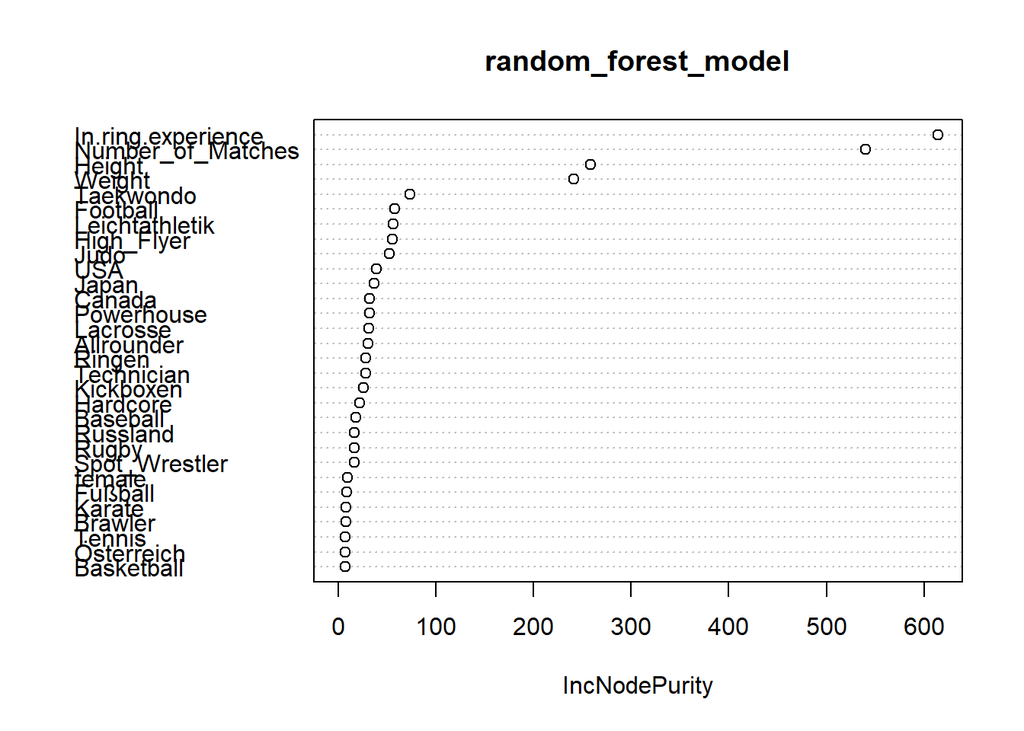

```r
varImpPlot(random_forest_model)
```

```r
nrow(fighter_data)
```

```
## [1] 69
```

This results show an overview of how certain factors might determine the win rate of a fighter. This results are not absolute since the sample base only took into account the top 100 fighters and their characteristics. Also, this analysis has certain limitations since the data since the data since many fighters did not had all these values, and the data had to be reduced to 70 fighters.

Personally, I think this results make sense since more seasoned fighters are more likely to win, and the more matches they have, the more likely they are to win. Also, the weight and height of a fighter are important factors in determining the outcome of a fight.